# Práctica 4. Trabajar con tablas o marcos de datos con R

Última actualización:

4 de marzo de 2026

# Preparación

En esta práctica trabajaremos en el entorno de R, con los paquetes siguientes: `dplyr`, `kableExtra` y `jsonlite`. Para descargar algunos datos de ejemplo, usaremos los programas `datasets` y `dataformat` (O’Leary et al. 2024), que pueden descargarse en [este enlace](https://www.ncbi.nlm.nih.gov/datasets/docs/v2/command-line-tools/download-and-install/).

# Objetivos

1. Conocer el uso de `datasets` y `dataformat`.
2. Ver algún ejemplo de archivo en formato JSON.
3. Manipular marcos de datos sin usar hojas de cálculo.

# Datos

Supón que tenemos interés en descargar un genoma de referencia de cualquier especie del género *Trypanosoma*, así como su anotación funcional, en formato [GFF3](https://github.com/The-Sequence-Ontology/Specifications/blob/master/gff3.md). Veamos primero de qué opciones disponemos:

```bash
if [ ! -e  ../../data/2026-02-17/trypanosoma_annotated.txt ]; then
   datasets summary genome taxon Trypanosoma --annotated --as-json-lines | \
   dataformat tsv genome --fields \
      accession,organism-name,assminfo-release-date,assminfo-level,assmstats-atgc-count,annotinfo-featcount-gene-total,assminfo-type,assminfo-status > ../../data/2026-02-17/trypanosoma_annotated.txt
fi
```

La línea larga que sigue a `--fields` especifica qué información sobre los genomas queremos ver en la tabla. Para saber qué campos se pueden seleccionar, puedes ejecutar la orden `dataformat tsv genome --help`. Veamos esa tabla en el informe HTML en un formato adecuado.

```r
library('knitr')
library('kableExtra')
genomas <- read.table('../../data/2026-02-17/trypanosoma_annotated.txt',
                      header = TRUE, sep = '\t')
kable(genomas) %>% kable_styling()
```

| Assembly.Accession | Organism.Name | Assembly.Release.Date | Assembly.Level | Assembly.Stats.ATGC.Count | Annotation.Count.Gene.Total | Assembly.Type | Assembly.Status |
| --- | --- | --- | --- | --- | --- | --- | --- |
| GCF_000002445.2 | Trypanosoma brucei brucei TREU927 | 2005-12-14 | Chromosome | 27984184 | 10221 | haploid | current |
| GCA_000002445.1 | Trypanosoma brucei brucei TREU927 | 2005-12-14 | Chromosome | 27984184 | 10234 | haploid | current |
| GCA_003543875.1 | Trypanosoma brucei equiperdum | 2018-09-11 | Chromosome | 26988976 | 10293 | haploid | current |
| GCF_000210295.1 | Trypanosoma brucei gambiense DAL972 | 2009-10-14 | Chromosome | 22110721 | 9930 | haploid | current |
| GCA_000210295.1 | Trypanosoma brucei gambiense DAL972 | 2009-10-14 | Chromosome | 22110721 | 9961 | haploid | current |
| GCA_000227395.2 | Trypanosoma congolense IL3000 | 2011-08-12 | Scaffold | 18802389 | 6348 | haploid | current |
| GCF_003719485.1 | Trypanosoma conorhini | 2018-11-08 | Scaffold | 21137671 | 10321 | haploid | current |
| GCA_003719485.1 | Trypanosoma conorhini | 2018-11-08 | Scaffold | 21137671 | 10321 | haploid | current |
| GCF_000209065.1 | Trypanosoma cruzi | 2005-08-02 | Scaffold | 89612356 | 25210 | unresolved-diploid | current |
| GCA_000188675.2 | Trypanosoma cruzi | 2012-10-02 | Contig | 38589511 | 10876 | haploid | current |
| GCA_000209065.1 | Trypanosoma cruzi | 2005-08-02 | Scaffold | 89612356 | 25210 | unresolved-diploid | current |
| GCA_003177095.1 | Trypanosoma cruzi | 2018-05-30 | Contig | 87058484 | 29302 | unresolved-diploid | current |
| GCA_003177105.1 | Trypanosoma cruzi | 2018-05-30 | Contig | 53271887 | 19115 | haploid | current |
| GCA_003719155.1 | Trypanosoma cruzi | 2018-11-05 | Scaffold | 20565523 | 34344 | diploid | current |
| GCA_003719455.1 | Trypanosoma cruzi | 2018-11-08 | Scaffold | 23852162 | 13503 | haploid | current |
| GCA_013358655.1 | Trypanosoma cruzi | 2020-06-18 | Scaffold | 40788336 | 14352 | haploid | current |
| GCA_015033625.1 | Trypanosoma cruzi | 2020-11-03 | Chromosome | 45527284 | 18708 | haploid | current |
| GCA_015033655.1 | Trypanosoma cruzi | 2020-11-03 | Chromosome | 47195002 | 17651 | haploid | current |
| GCA_002219105.2 | Trypanosoma cruzi cruzi | 2017-09-15 | Contig | 50928259 | 22870 | haploid | current |
| GCA_000496795.1 | Trypanosoma cruzi Dm28c | 2013-11-13 | Contig | 27304309 | 11398 | haploid | current |
| GCA_000300495.1 | Trypanosoma cruzi marinkellei | 2012-10-01 | Contig | 34226154 | 10127 | haploid | current |
| GCF_001457755.1 | Trypanosoma equiperdum | 2016-12-15 | Scaffold | 26113307 | 9129 | haploid | current |
| GCA_001457755.2 | Trypanosoma equiperdum | 2016-12-15 | Scaffold | 26113307 | 9135 | haploid | current |
| GCF_000691245.1 | Trypanosoma grayi | 2014-05-15 | Scaffold | 20791447 | 10676 | haploid | current |
| GCA_000691245.1 | Trypanosoma grayi | 2014-05-15 | Scaffold | 20791447 | 10676 | haploid | current |
| GCF_022059095.1 | Trypanosoma melophagium | 2022-02-08 | Contig | 23303718 | 9756 | haploid | current |
| GCA_022059095.1 | Trypanosoma melophagium | 2022-02-08 | Contig | 23303718 | 9768 | haploid | current |
| GCF_003719475.1 | Trypanosoma rangeli | 2018-11-08 | Scaffold | 20977846 | 10589 | haploid | current |
| GCA_003719475.1 | Trypanosoma rangeli | 2018-11-08 | Scaffold | 20977846 | 10589 | haploid | current |
| GCA_000492115.1 | Trypanosoma rangeli SC58 | 2013-10-30 | Contig | 15111138 | 7475 | haploid | current |
| GCF_002087225.1 | Trypanosoma theileri | 2017-04-12 | Scaffold | 25688935 | 11312 | haploid | current |
| GCA_002087225.1 | Trypanosoma theileri | 2017-04-12 | Scaffold | 25688935 | 11312 | haploid | current |
| GCA_021307395.1 | Trypanosoma vivax | 2021-12-28 | Contig | 67823889 | 17806 | haploid | current |
| GCA_019425475.1 | Trypanosoma vivax | 2021-07-30 | Contig | 23865041 | 10424 | haploid | current |
| GCA_000227375.1 | Trypanosoma vivax Y486 | 2011-08-11 | Contig | 24779298 | 4122 | haploid | current |

**NotaDesafío**

1. ¿Qué diferencia hay entre las líneas 7 y 8 de la tabla anterior?

   El identificador de la secuencia es distinto. En la línea 7 es GCF y en la 8 es GCA. Esto es porque provienen de bases de datos distintas, pero tienen la misma información.
2. Busca una función de R que te permita identificar las líneas repetidas en un marco de datos.

   Podemos consultar el dataframe con `genomas[c(7,8), ]`, que compara las filas 7 y 8 en todas sus columnas, por lo que podemos observar que solo cambia el nombre.

# Ordenar una tabla

La función `order()` produce los índices ordenados de los elementos de un vector. Consulta su ayuda y experimenta con ella. Vamos a usar esta función para ordenar las filas del marco de datos `genomas` por fecha, que es la tercera columna, llamada `Assembly.Release.Date`.

```r
# Observa que asignamos el resultado del ordenamiento al mismo objeto que
# estamos ordenando, para guardar el resultado sin tener que generar otro objeto.
genomas <- genomas[order(genomas$Assembly.Release.Date), ]
kable(genomas) %>% kable_styling()
```

|  | Assembly.Accession | Organism.Name | Assembly.Release.Date | Assembly.Level | Assembly.Stats.ATGC.Count | Annotation.Count.Gene.Total | Assembly.Type | Assembly.Status |
| --- | --- | --- | --- | --- | --- | --- | --- | --- |
| 9 | GCF_000209065.1 | Trypanosoma cruzi | 2005-08-02 | Scaffold | 89612356 | 25210 | unresolved-diploid | current |
| 11 | GCA_000209065.1 | Trypanosoma cruzi | 2005-08-02 | Scaffold | 89612356 | 25210 | unresolved-diploid | current |
| 1 | GCF_000002445.2 | Trypanosoma brucei brucei TREU927 | 2005-12-14 | Chromosome | 27984184 | 10221 | haploid | current |
| 2 | GCA_000002445.1 | Trypanosoma brucei brucei TREU927 | 2005-12-14 | Chromosome | 27984184 | 10234 | haploid | current |
| 4 | GCF_000210295.1 | Trypanosoma brucei gambiense DAL972 | 2009-10-14 | Chromosome | 22110721 | 9930 | haploid | current |
| 5 | GCA_000210295.1 | Trypanosoma brucei gambiense DAL972 | 2009-10-14 | Chromosome | 22110721 | 9961 | haploid | current |
| 35 | GCA_000227375.1 | Trypanosoma vivax Y486 | 2011-08-11 | Contig | 24779298 | 4122 | haploid | current |
| 6 | GCA_000227395.2 | Trypanosoma congolense IL3000 | 2011-08-12 | Scaffold | 18802389 | 6348 | haploid | current |
| 21 | GCA_000300495.1 | Trypanosoma cruzi marinkellei | 2012-10-01 | Contig | 34226154 | 10127 | haploid | current |
| 10 | GCA_000188675.2 | Trypanosoma cruzi | 2012-10-02 | Contig | 38589511 | 10876 | haploid | current |
| 30 | GCA_000492115.1 | Trypanosoma rangeli SC58 | 2013-10-30 | Contig | 15111138 | 7475 | haploid | current |
| 20 | GCA_000496795.1 | Trypanosoma cruzi Dm28c | 2013-11-13 | Contig | 27304309 | 11398 | haploid | current |
| 24 | GCF_000691245.1 | Trypanosoma grayi | 2014-05-15 | Scaffold | 20791447 | 10676 | haploid | current |
| 25 | GCA_000691245.1 | Trypanosoma grayi | 2014-05-15 | Scaffold | 20791447 | 10676 | haploid | current |
| 22 | GCF_001457755.1 | Trypanosoma equiperdum | 2016-12-15 | Scaffold | 26113307 | 9129 | haploid | current |
| 23 | GCA_001457755.2 | Trypanosoma equiperdum | 2016-12-15 | Scaffold | 26113307 | 9135 | haploid | current |
| 31 | GCF_002087225.1 | Trypanosoma theileri | 2017-04-12 | Scaffold | 25688935 | 11312 | haploid | current |
| 32 | GCA_002087225.1 | Trypanosoma theileri | 2017-04-12 | Scaffold | 25688935 | 11312 | haploid | current |
| 19 | GCA_002219105.2 | Trypanosoma cruzi cruzi | 2017-09-15 | Contig | 50928259 | 22870 | haploid | current |
| 12 | GCA_003177095.1 | Trypanosoma cruzi | 2018-05-30 | Contig | 87058484 | 29302 | unresolved-diploid | current |
| 13 | GCA_003177105.1 | Trypanosoma cruzi | 2018-05-30 | Contig | 53271887 | 19115 | haploid | current |
| 3 | GCA_003543875.1 | Trypanosoma brucei equiperdum | 2018-09-11 | Chromosome | 26988976 | 10293 | haploid | current |
| 14 | GCA_003719155.1 | Trypanosoma cruzi | 2018-11-05 | Scaffold | 20565523 | 34344 | diploid | current |
| 7 | GCF_003719485.1 | Trypanosoma conorhini | 2018-11-08 | Scaffold | 21137671 | 10321 | haploid | current |
| 8 | GCA_003719485.1 | Trypanosoma conorhini | 2018-11-08 | Scaffold | 21137671 | 10321 | haploid | current |
| 15 | GCA_003719455.1 | Trypanosoma cruzi | 2018-11-08 | Scaffold | 23852162 | 13503 | haploid | current |
| 28 | GCF_003719475.1 | Trypanosoma rangeli | 2018-11-08 | Scaffold | 20977846 | 10589 | haploid | current |
| 29 | GCA_003719475.1 | Trypanosoma rangeli | 2018-11-08 | Scaffold | 20977846 | 10589 | haploid | current |
| 16 | GCA_013358655.1 | Trypanosoma cruzi | 2020-06-18 | Scaffold | 40788336 | 14352 | haploid | current |
| 17 | GCA_015033625.1 | Trypanosoma cruzi | 2020-11-03 | Chromosome | 45527284 | 18708 | haploid | current |
| 18 | GCA_015033655.1 | Trypanosoma cruzi | 2020-11-03 | Chromosome | 47195002 | 17651 | haploid | current |
| 34 | GCA_019425475.1 | Trypanosoma vivax | 2021-07-30 | Contig | 23865041 | 10424 | haploid | current |
| 33 | GCA_021307395.1 | Trypanosoma vivax | 2021-12-28 | Contig | 67823889 | 17806 | haploid | current |
| 26 | GCF_022059095.1 | Trypanosoma melophagium | 2022-02-08 | Contig | 23303718 | 9756 | haploid | current |
| 27 | GCA_022059095.1 | Trypanosoma melophagium | 2022-02-08 | Contig | 23303718 | 9768 | haploid | current |

Casualmente, la fecha estaba en formato “%Y-%m-%d”, en el que el orden alfabético coincide con el orden temporal. Al crear `genomas`, `read.table()` había interpretado la tercera columna como texto. Para que las fechas sean entendidas como tales, podemos usar la función `as.Date()`:

```r
genomas$Assembly.Release.Date <- as.Date(genomas$Assembly.Release.Date,
                                         '%Y-%m-%d')
```

Una vez convertida en “fecha”, la columna “Assembly.Release.Date” puede usarse correctamente, por ejemplo, como eje de abscisas en una gráfica:

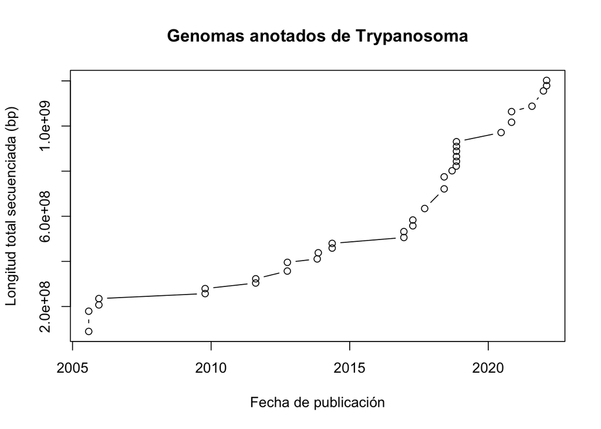

```r
# Aquí usamos "cumsum()" para obtener la suma acumulada del número de bases
# secuenciadas.
plot(x = genomas$Assembly.Release.Date,
     y = cumsum(genomas$Assembly.Stats.ATGC.Count),
     type = 'b',
     xlab = 'Fecha de publicación',
     ylab = 'Longitud total secuenciada (bp)',
     main = 'Genomas anotados de Trypanosoma')
```

# Archivos JSON y GFF

Habiendo visto las opciones, decidimos descargar el genoma y la anotación funcional de una de ellas, por ejemplo GCA_022059095.1.

```bash
if [ ! -e ../../data/2026-02-17/ncbi_data/data/GCA_022059095.1/genomic.gff ]; then
   cd ../../data/2026-02-17
   if [ ! -e ncbi_dataset.zip ]; then
      datasets download genome accession GCA_022059095.1 --include genome,gff3
   fi
   unzip ncbi_dataset.zip
fi
```

```
Archive:  ncbi_dataset.zip
replace README.md? [y]es, [n]o, [A]ll, [N]one, [r]ename:  NULL
(EOF or read error, treating as "[N]one" ...)
```

En la carpeta `ncbi_dataset/data` encontrarás un archivo en formato JSON con información sobre los datos descargados, y un archivo en formato “jsonlines”. El formato “jsonlines” es una versión de JSON en la que cada registro ocupa una sola línea. Esto dificulta la visualización, pero agiliza el análisis de los datos en la línea de órdenes. Para ver mejor el contenido del archivo con la extensión `jsonl`, podríamos utilizar el programa [`jq`](https://jqlang.org/), o bien utilizar la función `prettify()` del paquete `jsonlite` de R:

```r
library('jsonlite')
prettify(readLines('../../data/2026-02-17/ncbi_dataset/data/assembly_data_report.jsonl'))
```

```
{
    "assemblyInfo": {
        "assemblyLevel": "Contig",
        "assemblyName": "T.mel.1",
        "assemblyType": "haploid",
        "submitter": "University of Edinburgh",
        "refseqCategory": "reference genome",
        "bioprojectLineage": [
            {
                "bioprojects": [
                    {
                        "accession": "PRJNA786535",
                        "title": "Trypanosoma melophagium isolate:St. Kilda Genome sequencing and assembly"
                    }
                ]
            }
        ],
        "sequencingTech": "Oxford Nanopore MinION; DNBseq",
        "blastUrl": "https://blast.ncbi.nlm.nih.gov/Blast.cgi?PAGE_TYPE=BlastSearch&PROG_DEF=blastn&BLAST_SPEC=GDH_GCA_022059095.1",
        "biosample": {
            "accession": "SAMN23701209",
            "lastUpdated": "2021-12-29T05:45:01.878",
            "publicationDate": "2021-12-29T00:00:00.000",
            "submissionDate": "2021-12-06T10:53:03.556",
            "sampleIds": [
                {
                    "label": "Sample name",
                    "value": "T. melophagium"
                },
                {
                    "db": "SRA",
                    "value": "SRS11278131"
                }
            ],
            "description": {
                "title": "MIGS Eukaryotic sample from Trypanosoma melophagium",
                "organism": {
                    "taxId": 715481,
                    "organismName": "Trypanosoma melophagium"
                },
```

[output cut: 117 more lines]

```
        "wgsContigsUrl": "https://www.ncbi.nlm.nih.gov/Traces/wgs/JAJSEB01"
    },
    "currentAccession": "GCA_022059095.1",
    "accession": "GCA_022059095.1",
    "pairedAccession": "GCF_022059095.1",
    "sourceDatabase": "SOURCE_DATABASE_GENBANK",
    "organism": {
        "taxId": 715481,
        "organismName": "Trypanosoma melophagium",
        "infraspecificNames": {
            "ecotype": "St. Kilda",
            "isolate": "St. Kilda"
        }
    }
}
```

Volviendo a lo que nos interesa, vamos a cargar en un marco de datos de una sesión de R la anotación funcional del genoma escogido. Aunque existen funciones específicas para leer archivos GFF, usaremos la función básica `read.table()`, con alguna precaución.

```r
# Como no tiene cabecera, le damos los nombres de las columnas:
gff <- read.table('../../data/2026-02-17/ncbi_dataset/data/GCA_022059095.1/genomic.gff', sep = '\t',
                  col.names = c('seqid', 'source', 'type', 'start', 'end',
                                'score', 'strand', 'phase', 'attributes'),
                  quote = '')
```

Al leer el archivo GFF con `read.table()`, debemos especificar que el separador de columnas es el tabulador y que no hay texto entrecomillado en el archivo. Esto último se consigue con la opción `quote = ''`, y sirve para evitar que todo lo que se encuentre entre dos apóstrofes (*’*) se considere parte de un mismo campo de información, aunque sean cientos de líneas.

Para comprobar que el archivo ha sido leído completo y sin errores, conviene revisar las dimensiones del marco de datos (`dim(gff)`) o incluso visualizar el principio (`head(gff)`) y el final (`tail(gff)`) del objeto, que es demasiado grande para mostrarlo en pantalla completo.

## Seleccionar filas y columnas

En el objeto `gff` hay 5 valores diferentes de la variable `type`: “CDS”, “exon”, “gene”, “mRNA” y “region”. Puedes comprobarlo con `unique(gff$type)`, o con `table(gff$type)`. Podemos separar la tabla en cinco marcos de datos, que correspondan a esos cinco tipos de anotación funcional.

```r
# Usamos un vector booleano como índice de las filas.
# En las tablas nuevas, no necesitamos la tercera columna
# y la eliminamos con el "-3".

gene   <- gff[gff$type == 'gene',   -3]
mrna   <- gff[gff$type == 'mRNA',   -3]
exon   <- gff[gff$type == 'exon',   -3]
cds    <- gff[gff$type == 'CDS',    -3]
region <- gff[gff$type == 'region', -3]

# Alinear las órdenes nos ayuda a detectar posibles errores
```

**NotaDesafío**

Identifica en cada uno de estos marcos de datos qué columnas son invariables. Es decir, las columnas que tienen el mismo valor en todas las líneas. Y elimina esas columnas.

La función `summarise` del paquete dplyr muestra el número de variables distintas que hay en cada columnas.

```r
gene %>% summarise(across(everything(), n_distinct))
```

```
  seqid source start  end score strand phase attributes
1    64      1  9681 9701     1      2     1       9768
```

```r
mrna %>% summarise(across(everything(), n_distinct))
```

```
  seqid source start  end score strand phase attributes
1    64      1  9800 9876     1      2     1      10057
```

```r
exon %>% summarise(across(everything(), n_distinct))
```

```
  seqid source start   end score strand phase attributes
1    64      1 11002 11078     1      2     1      11304
```

```r
cds %>% summarise(across(everything(), n_distinct))
```

```
  seqid source start   end score strand phase attributes
1    64      1 11002 11078     1      2     3      10057
```

```r
region %>% summarise(across(everything(), n_distinct))
```

```
  seqid source start end score strand phase attributes
1    64      1     1  64     1      1     1         64
```

```r
# La columna 'start' de 'region' solo tiene una variable, pero no la eliminamos para así poder usarla en los calculos del desafío siguiente.
```

A continuación identificamos en cada marco de datos las columnas que tienen solo una variable (son invariables) y los eliminamos:

```r
gene <- gene[, -c(2, 5, 7)]
mrna <- mrna[, -c(2, 5, 7)]
exon <- exon[, -c(2, 5, 7)]
cds <- cds[, -c(2, 5)]
region <- region[, -c(2, 5, 6, 7)]
```

## Agrupar, operar y resumir

Habiendo separado los diferentes tipos de anotaciones, ahora resulta fácil obtener estadísticas de cada uno. Podemos querer una tabla que nos diga para cada tipo de anotación, cuántos elementos de ese tipo hay en el genoma, qué longitud media tienen y qué desviación estándar. Hay diferentes maneras de conseguirlo. La más rudimentaria implicaría obtener cada estadística individualmente y después juntarlas en una nueva tabla. Por ejemplo, para regiones codificantes (“CDS”):

```r
cds$longitud <- cds$end - cds$start + 1
resumen_cds <- data.frame(
   tipo       = 'CDS',
   número     = nrow(cds),
   long.Media = mean(cds$longitud),
   long.SD    = sd(cds$longitud)
)
```

**NotaDesafío**

¿Sabrías completar el marco de datos `resumen` con los datos de los otros cuatro tipos de anotación funcional?

Primero creamos los marcos de datos resumen de cada tipo de la misma manera que antes:

```r
gene$longitud <- gene$end - gene$start + 1
resumen_gene <- data.frame(
   tipo       = 'GENE',
   número     = nrow(gene),
   long.Media = mean(gene$longitud),
   long.SD    = sd(gene$longitud)
)
mrna$longitud <- mrna$end - mrna$start + 1
resumen_mrna <- data.frame(
   tipo       = 'mRNA',
   número     = nrow(mrna),
   long.Media = mean(mrna$longitud),
   long.SD    = sd(mrna$longitud)
)
exon$longitud <- exon$end - exon$start + 1
resumen_exon <- data.frame(
   tipo       = 'EXON',
   número     = nrow(exon),
   long.Media = mean(exon$longitud),
   long.SD    = sd(exon$longitud)
)
region$longitud <- region$end - region$start + 1
resumen_region <- data.frame(
   tipo       = 'REGION',
   número     = nrow(region),
   long.Media = mean(region$longitud),
   long.SD    = sd(region$longitud)
)
```

Una vez tenemos la tabla resumen de cada marco de datos las combinamos:

```r
resumen <- bind_rows(resumen_cds, resumen_exon, resumen_gene, resumen_mrna, resumen_region)
```

Este tipo de operación es bastante habitual, y se puede hacer sin necesidad de crear marcos de datos parciales. La función `split()` divide las líneas de un marco de datos en tantos marcos de datos como valores diferentes (*niveles*) haya en el *factor* que usemos para definir los grupos. El resultado es un solo objeto: una *lista* de marcos de datos:

```r
# Esto es una lista de marcos de datos:
porTipo <- split(gff, gff$type)

# Estas funciones nos permiten inspeccionar algunas características
# del nuevo objeto:
class(porTipo)
```

```
[1] "list"
```

```r
length(porTipo)
```

```
[1] 5
```

```r
names(porTipo)
```

```
[1] "CDS"    "exon"   "gene"   "mRNA"   "region"
```

```r
sapply(porTipo, class)
```

```
         CDS         exon         gene         mRNA       region
"data.frame" "data.frame" "data.frame" "data.frame" "data.frame"
```

```r
sapply(porTipo, nrow)
```

```
   CDS   exon   gene   mRNA region
 11304  11304   9768  10057     64
```

La función `sapply()`, toma al menos dos argumentos: una lista (o vector) y una función. Devuelve un vector (si es posible) con los resultados de aplicar la función a cada elemento de la lista. Con esto, el resumen que queríamos se puede obtener así:

```r
# Primero calculamos las longitudes de todas las anotaciones en gff:
gff$longitud <- gff$end - gff$start + 1

# Volvemos a separar las filas por tipo, ahora que tenemos las longitudes:
porTipo <- split(gff, gff$type)

resumen1 <- data.frame(
   tipo = names(porTipo),
   número = sapply(porTipo, nrow),
   long.Media = sapply(porTipo, function(x) mean(x$longitud)),
   long.SD    = sapply(porTipo, function(x)   sd(x$longitud))
)

# Aprovechamos para mostrar nombres de columnas más legibles:
kable(resumen,
      col.names = c('Tipo', 'Número', 'Longitud Media',
                    'Desviación estándar'),
      row.names = FALSE) %>%
   kable_styling(full_width = FALSE)
```

| Tipo | Número | Longitud Media | Desviación estándar |
| --- | --- | --- | --- |
| CDS | 11304 | 1358.661 | 1377.899 |
| EXON | 11304 | 1358.661 | 1377.899 |
| GENE | 9768 | 1553.822 | 1466.322 |
| mRNA | 10057 | 1549.331 | 1466.240 |
| REGION | 64 | 364120.594 | 314801.149 |

Las operaciones de agrupar y resumir se pueden hacer también con funciones del paquete `dplyr`, que forma parte de un conjunto de paquetes diseñados para funcionar armoniosamente entre ellos. Son los paquetes del [`tidyverse`](https://tidyverse.org/), muy populares en ciencia de datos. Casi se pueden considerar un dialecto de R. Las funciones (o *verbos*) más interesantes de `dplyr` son `group_by()` y `summarise()`.

```r
library('dplyr')
# Observa el uso de "tuberías" ("%>%"):
resumen1 <- gff %>% group_by(type) %>% summarise(
   número     = n(),
   Long.Media = mean(longitud),
   Long.SD    = sd(longitud)
)
kable(resumen1,
      col.names = c('Tipo', 'Número', 'Longitud Media',
                    'Desviación estándar'),
      row.names = FALSE) %>%
   kable_styling(full_width = FALSE)
```

| Tipo | Número | Longitud Media | Desviación estándar |
| --- | --- | --- | --- |
| CDS | 11304 | 1358.661 | 1377.899 |
| exon | 11304 | 1358.661 | 1377.899 |
| gene | 9768 | 1553.822 | 1466.322 |
| mRNA | 10057 | 1549.331 | 1466.240 |
| region | 64 | 364120.594 | 314801.149 |

**NotaDesafío**

Crea una tabla con el número total de genes en cada cromosoma. ¿Puedes contar cuántos hay codificados en cada sentido (“strand”) y en cada cromosoma?

```r
library(kableExtra)
library(tidyr)
library(dplyr)
desafio <- gene %>%
  #Agrupamos los datos de seqid y strand de la tabla gene, que es la que ya tenía solo los genes.
  group_by(seqid, strand) %>%
  #Crea una columna temporal en la que cuenta el número de genes (líneas) de cada cromosoma (seqid)
  summarise(num_gene = n(), .groups = 'drop') %>%
  #Separamos las variables de la columna 'strand' en dos nuevas columnas, que se rellenan con los datos de la columna num_gene anterior. Si no hay genes de alguna de ellas, se rellena con un 0.
  pivot_wider(names_from = strand, values_from = num_gene, values_fill = 0) %>%
  #Añade una nueva columna que sume los valores de las hebras.
  mutate(total_gene = rowSums(across(-seqid)))
kable(desafio,
      col.names = c('Cromosoma', 'Strand +', 'Strand -', 'Genes'),
      row.names = FALSE) %>%
   kable_styling(full_width = FALSE)
```

| Cromosoma | Strand + | Strand - | Genes |
| --- | --- | --- | --- |
| JAJSEB010000001.1 | 376 | 201 | 577 |
| JAJSEB010000002.1 | 0 | 3 | 3 |
| JAJSEB010000003.1 | 0 | 39 | 39 |
| JAJSEB010000004.1 | 34 | 14 | 48 |
| JAJSEB010000005.1 | 32 | 114 | 146 |
| JAJSEB010000006.1 | 208 | 10 | 218 |
| JAJSEB010000007.1 | 74 | 129 | 203 |
| JAJSEB010000008.1 | 28 | 58 | 86 |
| JAJSEB010000009.1 | 84 | 8 | 92 |
| JAJSEB010000010.1 | 32 | 0 | 32 |
| JAJSEB010000011.1 | 84 | 104 | 188 |
| JAJSEB010000012.1 | 150 | 35 | 185 |
| JAJSEB010000013.1 | 138 | 41 | 179 |
| JAJSEB010000014.1 | 145 | 48 | 193 |
| JAJSEB010000015.1 | 30 | 0 | 30 |
| JAJSEB010000016.1 | 56 | 164 | 220 |
| JAJSEB010000017.1 | 87 | 87 | 174 |
| JAJSEB010000018.1 | 163 | 364 | 527 |
| JAJSEB010000019.1 | 86 | 126 | 212 |
| JAJSEB010000020.1 | 20 | 163 | 183 |
| JAJSEB010000021.1 | 162 | 126 | 288 |
| JAJSEB010000022.1 | 74 | 110 | 184 |
| JAJSEB010000023.1 | 38 | 1 | 39 |
| JAJSEB010000024.1 | 126 | 116 | 242 |
| JAJSEB010000025.1 | 128 | 16 | 144 |
| JAJSEB010000026.1 | 223 | 91 | 314 |
| JAJSEB010000027.1 | 174 | 53 | 227 |
| JAJSEB010000028.1 | 30 | 66 | 96 |
| JAJSEB010000029.1 | 126 | 8 | 134 |
| JAJSEB010000030.1 | 66 | 46 | 112 |
| JAJSEB010000031.1 | 222 | 222 | 444 |
| JAJSEB010000032.1 | 20 | 164 | 184 |
| JAJSEB010000033.1 | 100 | 13 | 113 |
| JAJSEB010000034.1 | 4 | 0 | 4 |
| JAJSEB010000035.1 | 37 | 63 | 100 |
| JAJSEB010000036.1 | 25 | 124 | 149 |
| JAJSEB010000037.1 | 5 | 6 | 11 |
| JAJSEB010000038.1 | 3 | 7 | 10 |
| JAJSEB010000039.1 | 4 | 4 | 8 |
| JAJSEB010000040.1 | 21 | 138 | 159 |
| JAJSEB010000041.1 | 112 | 86 | 198 |
| JAJSEB010000042.1 | 51 | 60 | 111 |
| JAJSEB010000043.1 | 91 | 87 | 178 |
| JAJSEB010000044.1 | 31 | 0 | 31 |
| JAJSEB010000045.1 | 58 | 52 | 110 |
| JAJSEB010000046.1 | 25 | 0 | 25 |
| JAJSEB010000047.1 | 29 | 15 | 44 |
| JAJSEB010000048.1 | 184 | 212 | 396 |
| JAJSEB010000049.1 | 17 | 1 | 18 |
| JAJSEB010000050.1 | 13 | 1 | 14 |
| JAJSEB010000051.1 | 1 | 23 | 24 |
| JAJSEB010000052.1 | 0 | 1 | 1 |
| JAJSEB010000053.1 | 4 | 0 | 4 |
| JAJSEB010000054.1 | 0 | 2 | 2 |
| JAJSEB010000055.1 | 5 | 0 | 5 |
| JAJSEB010000056.1 | 235 | 228 | 463 |
| JAJSEB010000057.1 | 0 | 14 | 14 |
| JAJSEB010000058.1 | 209 | 205 | 414 |
| JAJSEB010000059.1 | 54 | 128 | 182 |
| JAJSEB010000060.1 | 56 | 279 | 335 |
| JAJSEB010000061.1 | 123 | 59 | 182 |
| JAJSEB010000062.1 | 59 | 2 | 61 |
| JAJSEB010000063.1 | 160 | 265 | 425 |
| JAJSEB010000064.1 | 6 | 28 | 34 |

# Comparar o cruzar datos

Imagina que un estudio señala los cromosomas siguientes como posiblemente asociados a la resistencia a un fármaco. Quieres saber qué genes hay en estos cinco cromosomas:

- JAJSEB010000048.1
- JAJSEB010000012.1
- JAJSEB010000020.1
- JAJSEB010000016.1
- JAJSEB010000033.1

Antes hemos usado el operador lógico `==` para crear un vector booleano con el que seleccionar algunas líneas. En este caso usaremos el operador `%in%`, que compara conjuntos o vectores de caracteres:

```r
candidatos <- c("JAJSEB010000048.1",
                "JAJSEB010000012.1",
                "JAJSEB010000020.1",
                "JAJSEB010000016.1",
                "JAJSEB010000033.1")
interesantes <- gff[gff$seqid %in% candidatos, ]
dim(interesantes)
```

```
[1] 4792   10
```

**NotaDesafío**

¿Puedes limitar la selección a anotaciones de tipo “gene”?

Partimos de la tabla gene en lugar de la general gff y filtramos comparando con los cromosomas (seqid) candidatos.

```r
candidatos <- c("JAJSEB010000048.1",
                "JAJSEB010000012.1",
                "JAJSEB010000020.1",
                "JAJSEB010000016.1",
                "JAJSEB010000033.1")
interesantes <- gene[gene$seqid %in% candidatos, ]
dim(interesantes)
```

```
[1] 1097    6
```

El estudio avanza y reduce el tamaño de las regiones candidatas, así que ahora necesitas identificar los genes presentes en exactamente las regiones siguientes:

- JAJSEB010000048.1:184638-253478
- JAJSEB010000012.1:133444-348860
- JAJSEB010000020.1:73393-149614
- JAJSEB010000016.1:161247-272009
- JAJSEB010000033.1:123135-170687

Aunque existen programas específicos para comparar segmentos cromosómicos ([bedtools](https://github.com/arq5x/bedtools2)), continuaremos practicando con marcos de datos de R. Ahora ya no podemos usar `%in%`, porque de cada cromosoma queremos unos segmentos diferentes. Una estrategia es crear cinco filtros booleanos, y después combinarlos con la operación lógica “o”, es decir `|`. En cada filtro seleccionaremos las anotaciones que estén completamente contenidas en el intervalo indicado.

```r
f1 <- gff$seqid == 'JAJSEB010000048.1' & gff$start >= 184638 & gff$end <= 253478
f2 <- gff$seqid == 'JAJSEB010000012.1' & gff$start >= 133444 & gff$end <= 348860
f3 <- gff$seqid == 'JAJSEB010000020.1' & gff$start >= 73393  & gff$end <= 149614
f4 <- gff$seqid == 'JAJSEB010000016.1' & gff$start >= 161247 & gff$end <= 272009
f5 <- gff$seqid == 'JAJSEB010000033.1' & gff$start >= 123135 & gff$end <= 170687

f <- f1 | f2 | f3 | f4 | f5

interesantes <- gff[f, ]
```

**NotaDesafío**

¿Puedes cambiar los filtros para que incluyan también genes *parcialmente* contenidos en los intervalos indicados?

```r
f1 <- gff$seqid == 'JAJSEB010000048.1' & ((gff$start >= 184638 & gff$start <= 253478) | (gff$end >= 184638 & gff$end <= 253478))
f2 <- gff$seqid == 'JAJSEB010000012.1' & ((gff$start >= 133444 & gff$start <= 348860) | (gff$end >= 133444 & gff$end <= 348860))
f3 <- gff$seqid == 'JAJSEB010000020.1' & ((gff$start >= 73393  & gff$start <= 149614) | (gff$end >= 73393  & gff$end <= 149614))
f4 <- gff$seqid == 'JAJSEB010000016.1' & ((gff$start >= 161247 & gff$start <= 272009) | (gff$end >= 161247 & gff$end <= 272009))
f5 <- gff$seqid == 'JAJSEB010000033.1' & ((gff$start >= 123135 | gff$start <= 170687) | (gff$end >= 123135 | gff$end <= 170687))

f <- f1 | f2 | f3 | f4 | f5

interesantes <- gff[f, ]
```

# Las llaves y la función `match()`

En las bases de datos relacionales se llama *llave* a la columna o al conjunto de columnas cuyos valores identifican unívocamente cada línea de la tabla. En los marcos de datos de R, las líneas pueden tener nombre, el cual puede usarse como *llave* o índice para seleccionar líneas. Pero el uso del nombre de las líneas no es recomendable. Lo más práctico es que en cualquier tabla haya una columna cuyos valores no puedan repetirse. Esto ayuda a evitar duplicidades, mantener la integridad de la tabla y relacionar unas tablas con otras.

**Nota**

¿Cuál es la *llave* en un archivo GFF?

La columna ‘attributes’ contiene el identificador de cada secuencia, que es la única variable única de cada secuencia.

El código siguiente descarga la tabla de genomas de *Trypanosoma* ensamblados a nivel de cromosoma, de la [European Nucleotide Archive](https://www.ebi.ac.uk/ena/)

```r
# Aprenderemos esta sintaxis en el próximo tema:
portal <- 'https://www.ebi.ac.uk/ena/portal/api/search?'
result <- 'result=assembly&'
query  <- 'query=tax_tree(5690)&'
fields <- 'fields=accession%2Cversion%2Cscientific_name%2Cbase_count%2Clast_updated%2Cassembly_level'
URL <- paste0(portal, result, query, fields)
genomas.ena <- read.table(URL, header = TRUE, sep = '\t', quote = '', na.strings = '')
```

Tanto el nuevo marco de datos `genomas.ena`, como el que habíamos creado antes con datos de NCBI, `genomas`, tienen una columna de valores únicos: “accession” o “Assembly.Accession”. Para los registros comunes entre las dos tablas, podemos transferir información de una a otra. Por ejemplo, vamos a añadir a la tabla `genomas` la fecha de última modificación del ensamblaje, que encontramos en `genomas.ena`. Para asegurarnos de que a cada ensamblaje le asignamos el valor correcto, usaremos la función `match()`.

En `genomas`, “Assembly.Accession” incluye un sufijo que indica el número de versión del ensamblaje. Este sufijo no está presente en `genomas.ena$accession`. Para hacer comparables ambas tablas, quitaremos el sufijo de la primera tabla.

```r
# Este es un uso avanzado de `sapply()` y `strsplit()`:
genomas$acc <- sapply(
   strsplit(genomas$Assembly.Accession, '.', fixed = TRUE),
   '[', 1
)

genomas$last_updated <- genomas.ena[match(genomas$acc,
                                          genomas.ena$accession),
                                    'last_updated']
```

**NotaDesafíos**

1. ¿Cómo comprobarías que al eliminar el sufijo de la versión, `genomas$acc` sigue siendo una *llave* de la tabla `genomas`?

   Comprobamos las dimensiones de la tabla (para saber la cantidad de secuencias contenidas) y la cantidad de variables distintas de cada columna. En este caso vemos que la tabla tiene 35 filas y el número de variables distintas en la columna acc también es 35, por lo que podemos considerar que esta sigue siendo una llave de la tabla.

   ```r
   dim(genomas)
   ```

   ```
   [1] 35 10
   ```

   ```r
   genomas %>% summarise(across(everything(), n_distinct))
   ```

   ```
     Assembly.Accession Organism.Name Assembly.Release.Date Assembly.Level
   1                 35            17                    22              3
     Assembly.Stats.ATGC.Count Annotation.Count.Gene.Total Assembly.Type
   1                        26                          30             3
     Assembly.Status acc last_updated
   1               1  35           20
   ```

2. Siguiendo el mismo esquema añade a `genomas` el “base_count” y compáralo con el “Assembly.Stats.ATGC.Count”. Si observas alguna diferencia, intenta explicarla.

   En este caso tenemos que tener en cuenta que debemos mantener el argumento match igual, porque las columnas acc y accession son las que tienen las llaves, que es en lo que nos basamos para hacer el match.

   ```r
   genomas$base_count <- genomas.ena[match(genomas$acc, genomas.ena$accession), 'base_count']
   ```

## Apéndice

En los archivos GFF, la columna `attributes` es una lista de parejas de valores “clave = valor”, separadas por punto y coma (“;”). Habiendo creado antes un marco de datos para cada tipo de anotación (genes, CDS, etc.), es de suponer que todas las líneas de un marco de datos tendrán el mismo conjunto de parejas “clave = valor”. Aquí se muestra una manera de extraer esta información y convertirla en columnas adicionales de un marco de datos.

Veamos el primer valor de `attributes` en el marco de datos `gene`:

```r
gene[1, 'attributes']
```

```
[1] "ID=gene-LSM04_009031;Name=LSM04_009031;gbkey=Gene;gene_biotype=protein_coding;locus_tag=LSM04_009031"
```

La función `strsplit()` en R divide una cadena de caracteres en partes delimitadas por algún carácter o expresión regular. En este caso, queremos dividir esa cadena por los puntos y coma:

```r
strsplit(gene[1, 'attributes'], ';')
```

```
[[1]]
[1] "ID=gene-LSM04_009031"        "Name=LSM04_009031"
[3] "gbkey=Gene"                  "gene_biotype=protein_coding"
[5] "locus_tag=LSM04_009031"
```

`strsplit()` ha dividido la cadena de caracteres original en una *lista* que contiene un único vector de cinco cadenas de caracteres. El motivo de generar una lista en lugar de un simple vector es que `strsplit()` puede actuar simultáneamente sobre todas las cadenas de caracteres de un vector, y necesita repartir el resultado en diferentes vectores:

```r
strsplit(gene[1:3, 'attributes'], ';')
```

```
[[1]]
[1] "ID=gene-LSM04_009031"        "Name=LSM04_009031"
[3] "gbkey=Gene"                  "gene_biotype=protein_coding"
[5] "locus_tag=LSM04_009031"

[[2]]
[1] "ID=gene-LSM04_007573"        "Name=LSM04_007573"
[3] "gbkey=Gene"                  "gene_biotype=protein_coding"
[5] "locus_tag=LSM04_007573"

[[3]]
[1] "ID=gene-LSM04_000706"        "Name=LSM04_000706"
[3] "gbkey=Gene"                  "gene_biotype=protein_coding"
[5] "locus_tag=LSM04_000706"
```

Podemos guardar la lista de los vectores de los atributos de cada gen en un nuevo objeto, para continuar operando sobre el después:

```r
atributos <- strsplit(gene[ , 'attributes'], ';')

# Veamos los 6 primeros elementos:
head(atributos)
```

```
[[1]]
[1] "ID=gene-LSM04_009031"        "Name=LSM04_009031"
[3] "gbkey=Gene"                  "gene_biotype=protein_coding"
[5] "locus_tag=LSM04_009031"

[[2]]
[1] "ID=gene-LSM04_007573"        "Name=LSM04_007573"
[3] "gbkey=Gene"                  "gene_biotype=protein_coding"
[5] "locus_tag=LSM04_007573"

[[3]]
[1] "ID=gene-LSM04_000706"        "Name=LSM04_000706"
[3] "gbkey=Gene"                  "gene_biotype=protein_coding"
[5] "locus_tag=LSM04_000706"

[[4]]
[1] "ID=gene-LSM04_000559"        "Name=LSM04_000559"
[3] "gbkey=Gene"                  "gene_biotype=protein_coding"
[5] "locus_tag=LSM04_000559"

[[5]]
[1] "ID=gene-LSM04_006454"        "Name=LSM04_006454"
[3] "gbkey=Gene"                  "gene_biotype=protein_coding"
[5] "locus_tag=LSM04_006454"

[[6]]
[1] "ID=gene-LSM04_009090"        "Name=LSM04_009090"
[3] "gbkey=Gene"                  "gene_biotype=protein_coding"
[5] "locus_tag=LSM04_009090"
```

```r
# Y la longitud total de la lista:
length(atributos)
```

```
[1] 9768
```

Una vez tenemos una lista de los atributos de cada gen, podemos usar funciones de la familia `lapply()` para operar en paralelo sobre todos sus elementos. Examina la ayuda de `lapply()` para familiarizarte con estas funciones. A continuación, la usaremos para separar la clave del valor en todos los atributos de todos los genes. Además asignaremos la clave como nombre del valor correspondiente (en R, los elementos de un vector pueden tener nombre).

```r
atributos2 <- lapply(
   atributos,
   # Definimos una función para aplicarla a cada elemento de "atributos".
   function(x) {
      # "x" es un vector de atributos de un solo gen
      lista <- strsplit(x, '=')
      # "lista" es una lista de vectores de 2 componentes, clave y valor
      valores <- sapply(lista, '[', 2)
      names(valores) <- sapply(lista, '[', 1)
      return(valores)
   }
)
head(atributos2)
```

```
[[1]]
                 ID                Name               gbkey        gene_biotype
"gene-LSM04_009031"      "LSM04_009031"              "Gene"    "protein_coding"
          locus_tag
     "LSM04_009031"

[[2]]
                 ID                Name               gbkey        gene_biotype
"gene-LSM04_007573"      "LSM04_007573"              "Gene"    "protein_coding"
          locus_tag
     "LSM04_007573"

[[3]]
                 ID                Name               gbkey        gene_biotype
"gene-LSM04_000706"      "LSM04_000706"              "Gene"    "protein_coding"
          locus_tag
     "LSM04_000706"

[[4]]
                 ID                Name               gbkey        gene_biotype
"gene-LSM04_000559"      "LSM04_000559"              "Gene"    "protein_coding"
          locus_tag
     "LSM04_000559"

[[5]]
                 ID                Name               gbkey        gene_biotype
"gene-LSM04_006454"      "LSM04_006454"              "Gene"    "protein_coding"
          locus_tag
     "LSM04_006454"

[[6]]
                 ID                Name               gbkey        gene_biotype
"gene-LSM04_009090"      "LSM04_009090"              "Gene"    "protein_coding"
          locus_tag
     "LSM04_009090"
```

El orden de los atributos se ha mantenido idéntico al orden de sus correspondientes genes. Por eso podemos ahora añadir las columnas de atributos que queramos al marco de datos `gene`:

```r
gene$ID           <- sapply(atributos2, '[', 'ID')
gene$Name         <- sapply(atributos2, '[', 'Name')
gene$gene_biotype <- sapply(atributos2, '[', 'gene_biotype')
gene$locus_tag    <- sapply(atributos2, '[', 'locus_tag')

f <- names(gene) != 'attributes'
kable(gene[1:15, f]) %>% kable_styling()
```

|  | seqid | start | end | strand | longitud | ID | Name | gene_biotype | locus_tag |
| --- | --- | --- | --- | --- | --- | --- | --- | --- | --- |
| 2 | JAJSEB010000004.1 | 246 | 935 | - | 690 | gene-LSM04_009031 | LSM04_009031 | protein_coding | LSM04_009031 |
| 8 | JAJSEB010000004.1 | 2204 | 2776 | + | 573 | gene-LSM04_007573 | LSM04_007573 | protein_coding | LSM04_007573 |
| 12 | JAJSEB010000004.1 | 3011 | 3706 | + | 696 | gene-LSM04_000706 | LSM04_000706 | protein_coding | LSM04_000706 |
| 16 | JAJSEB010000004.1 | 4768 | 4986 | + | 219 | gene-LSM04_000559 | LSM04_000559 | protein_coding | LSM04_000559 |
| 20 | JAJSEB010000004.1 | 5540 | 8959 | + | 3420 | gene-LSM04_006454 | LSM04_006454 | protein_coding | LSM04_006454 |
| 24 | JAJSEB010000004.1 | 9198 | 9512 | + | 315 | gene-LSM04_009090 | LSM04_009090 | protein_coding | LSM04_009090 |
| 28 | JAJSEB010000004.1 | 9877 | 12936 | + | 3060 | gene-LSM04_002876 | LSM04_002876 | protein_coding | LSM04_002876 |
| 32 | JAJSEB010000004.1 | 13160 | 14620 | + | 1461 | gene-LSM04_001088 | LSM04_001088 | protein_coding | LSM04_001088 |
| 36 | JAJSEB010000004.1 | 14840 | 16024 | + | 1185 | gene-LSM04_006263 | LSM04_006263 | protein_coding | LSM04_006263 |
| 40 | JAJSEB010000004.1 | 16367 | 16935 | + | 569 | gene-LSM04_007732 | LSM04_007732 | protein_coding | LSM04_007732 |
| 46 | JAJSEB010000004.1 | 17016 | 17411 | + | 396 | gene-LSM04_006531 | LSM04_006531 | protein_coding | LSM04_006531 |
| 52 | JAJSEB010000004.1 | 17834 | 19039 | + | 1206 | gene-LSM04_007917 | LSM04_007917 | protein_coding | LSM04_007917 |
| 56 | JAJSEB010000004.1 | 19420 | 20313 | + | 894 | gene-LSM04_009571 | LSM04_009571 | protein_coding | LSM04_009571 |
| 60 | JAJSEB010000004.1 | 20625 | 21875 | + | 1251 | gene-LSM04_003035 | LSM04_003035 | protein_coding | LSM04_003035 |
| 64 | JAJSEB010000004.1 | 22111 | 22929 | + | 819 | gene-LSM04_003619 | LSM04_003619 | protein_coding | LSM04_003619 |

## Bibliografía

O’Leary, N. A., E. Cox, J. B. Holmes, W. R. Anderson, R. Falk, V. Hem, M. T. N. Tsuchiya, et al. 2024. «Exploring and retrieving sequence and metadata for species across the tree of life with NCBI datasets». *Scientific Data* 11: 732. https://doi.org/10.1038/s41597-024-03571-y.